# HW4) Graphics with ggplot2

Stat 133, Fall 2024

Author

Wenyi Shi

**General Instructions**

- Write your code and content in a `qmd` (quarto markdown) file. You can use the template file `hw4-template.qmd` provided in bCourses.
- Name this file as `hw4-first-last.qmd`, where `first` and `last` are your first and last names (e.g. `hw4-gaston-sanchez.qmd`).
- Make sure the YAML header in your `qmd` files includes `embed-resources: true`
- Submit both your qmd and HTML files to the corresponding assignment submission in bCourses.
- Please note that submitting only one of the files will result in an automatic 10% deduction.
- Also, if you submit the incorrect files you will receive no credit.

# NBA Data (2022 Season)

This HW involves visualizing some variables of NBA players (from the 2022 regular season) by using functions from the tidyverse package `"ggplot2"`.

## Importing the Data

The data file `"nba2022-clean.csv"` is located in bCourses, in the same assignment folder with this HTML file of instructions.

The code below allows you to import the data in R. As you can tell, `read_csv()` imports the file `"nba2022-clean.csv"`. In turn, the `col_types` argument is used to specify data-types for each of the columns:

```r
dat = read_csv(
  file = "nba2022-clean.csv",
  col_types = cols(
    player = col_character(),      # name of player
    team = col_character(),        # team (3-letter abbreviation)
    position = col_character(),    # abbreviated
    height = col_double(),         # height in inches
    weight = col_double(),         # weight in pounds
    age = col_double(),            # age in years
    experience = col_double(),     # years playing professionally
    salary = col_double(),         # salary in dollars
    games = col_double(),          # number of played games
    points3 = col_double(),        # number of triple-pointers
    points2 = col_double(),        # number of two-pointers
    points1 = col_double(),        # number of free-throws
    total_rebounds = col_double(), # defensive & offensive rebounds
    assists = col_double(),        # number of assists
    blocks = col_double(),         # number of blocks
    turnovers = col_double()       # number of turnovers
  ))
```

# 1 Very Specific Prompts: Age of NBA players

**Important**

- All the graphics must include a meaningful title.
- Including a subtitle would be nice but it’s not mandatory.
- Make sure axes are labeled.

## 1.1 Histogram of Age

Use *ggplot* functions to generate a histogram of `age`. Choose an adequate number of bins or a bin-width value. Also, provide a concise description of the displayed distribution.

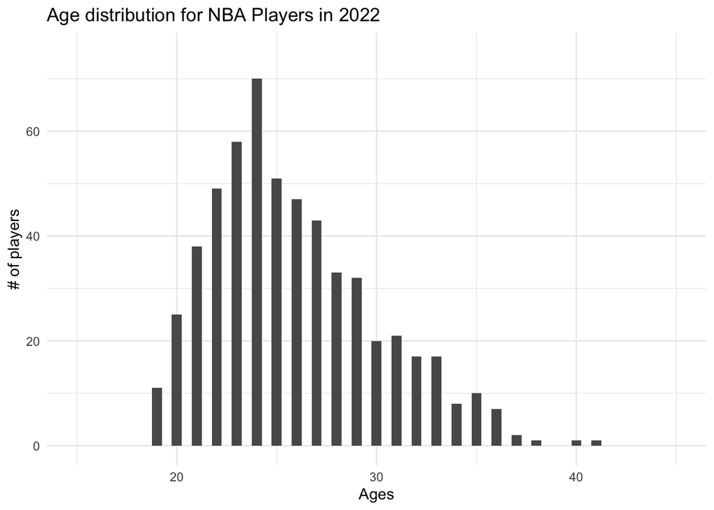

```r
# your code
ggplot(data = dat, aes(x = age)) +
  geom_histogram(binwidth = 0.5) +
  scale_x_continuous(limits = c(15, 45)) +
  scale_y_continuous(limits = c(0, 75)) +
  labs(title = "Age distribution for NBA Players in 2022",
       x = "Ages",
       y = "# of players") +
  theme_minimal()
```

## 1.2 Density plots of Age by Position

Use *ggplot* functions to generate density plots of `age`, **faceting** by `position`. Fill the densities (i.e. fill the area under the curve) with a color of your choice. Use a theme that is not the default one. And provide a description of the displayed densities.

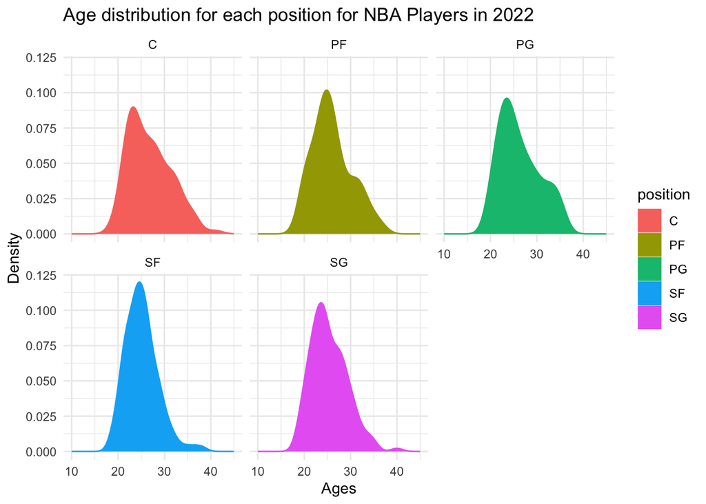

```r
# your code
ggplot(data = dat, aes(x = age, color = position)) +
  geom_density(aes(fill = position)) +
  scale_x_continuous(limits = c(10, 45)) +
  facet_wrap(~ position) +
  labs(title = "Age distribution for each position for NBA Players in 2022",
       x = "Ages",
       y = "Density") +
  theme_minimal()
```

## 1.3 Weight and Age of LAC players

Consider the code given below. It allows you to graph a scatter plot of `height` and `turnovers` of Boston Celtics players. It also displays the last name of each player right next to the associated x-y point.

```r
# Boston Celtics
lakers = filter(dat, team == "BOS")

# scatter plot of height and turnovers
ggplot(data = lakers, aes(x = height, y = turnovers)) +
  geom_point() +
  geom_text(aes(label = str_extract(player, "\\w+$")), hjust = -0.1)
```

Use the provided sample code to produce a scatter plot of `age` and `weight` for Los Angeles Clippers (LAC) players. Use `position` to color-code the players (both the points and their last names). In addition, use `scale_x_continuous()` to adjust the x-axis scale so that its limits range from 20 to 36. Do the same for the y-axis—via `scale_y_continuous()`—so that its limits range from 160 to 260. Lastly, use a theme that is not the default one, and don’t forget to include a title.

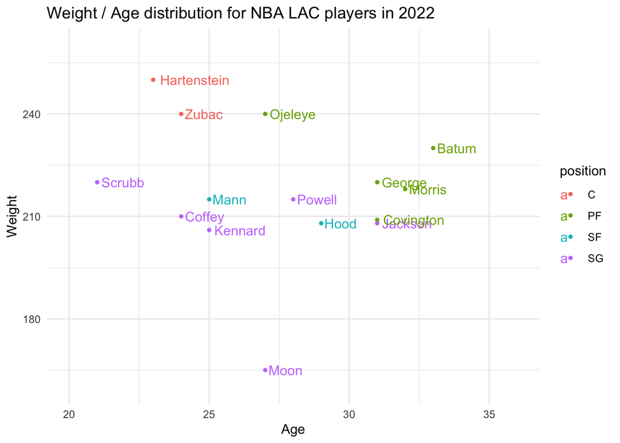

```r
# your code
lakers = filter(dat, team == "LAC")

# scatter plot of height and turnovers
ggplot(data = lakers, aes(x = age, y = weight)) +
  geom_point(aes(color = position), size = 1) +
  geom_text(aes(label = str_extract(player, "\\w+$"), color = position), hjust = -0.1) +
  scale_x_continuous(limits = c(20, 36)) +
  scale_y_continuous(limits = c(160, 260)) +
  labs(title = "Weight / Age distribution for NBA LAC players in 2022",
       x = "Age",
       y = "Weight") +
  theme_minimal()
```

## 1.4 Boxplots of Age, by Experience

Refer to the data set `dat`. Without using facets, write *ggplot* commands to generate boxplots of `age`, by years of `experience`. For graphing purposes, use `factor(experience)` so that ggplot treats `experience` as a discrete variable instead of a continuous one. Likewise, include a title, possibly a subtitle, nice axis labels, and use a theme that is not the default one. Also, provide a description of the displayed distributions, potential outliers, interesting patterns, etc.

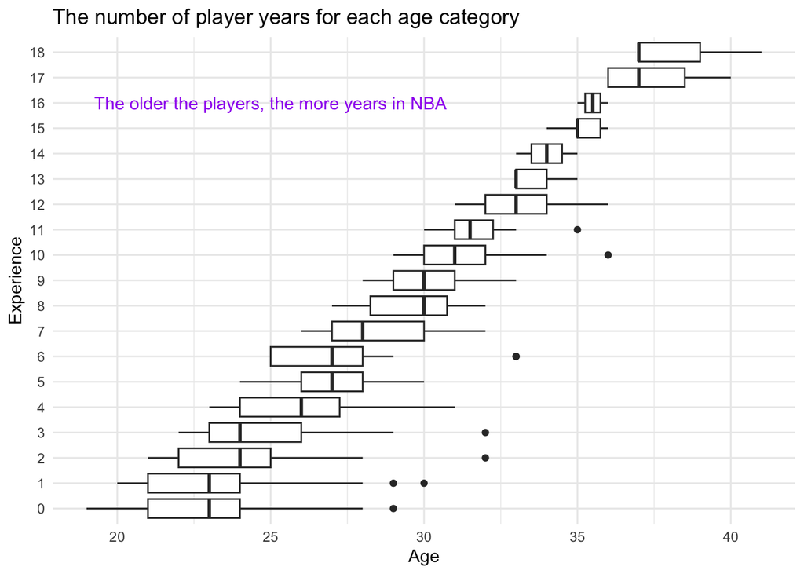

```r
# your code
ggplot(data = dat, aes(x = age, y = factor(experience))) +
  geom_boxplot() +
  labs(title = "The number of player years for each age category",
       x = "Age",
       y = "Experience") +
  theme_minimal() +
  annotate(geom = "text", x = 25, y = 17, label = "The older the players, the more years in NBA", color = "purple")
```

# 2 Somewhat open-ended questions

Answer the following questions. Generate appropriate graphics to support your conclusions. To be clear: answer each question with a graphic, and a brief description of what’s going on in the plot.

**Important**

- You are **not** allowed to use `"dplyr"` commands or do any manipulation on the data.
- All the graphics must include a meaningful title.
- Make sure axes are labeled.

## 2.1 Age and Team

Generate a single graphic that lets you visualize the age of players, by team, in order to answer the following parts:

1. Which team has the oldest player? **MIA (Miami)**
2. How many teams have players younger than 20-years old? **7**

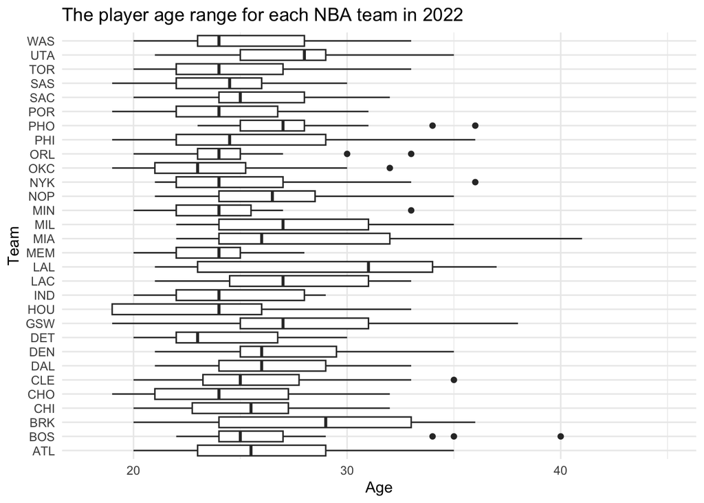

```r
# your code
ggplot(data = dat, aes(x = age, y = team)) +
  geom_boxplot() +
  scale_x_continuous(limits = c(18, 45)) +
  labs(title = "The player age range for each NBA team in 2022",
       x = "Age",
       y = "Team") +
  theme_minimal()
```

## 2.2 Turnovers and Blocks

In basketball:

- a **turnover** occurs when a team loses possession of the ball to the opposing team before a player takes a shot at their team’s basket.
- a **block** or *blocked shot* occurs when a defensive player legally deflects a field goal attempt from an offensive player to prevent a score. The defender is not allowed to make contact with the offensive player’s hand (unless the defender is also in contact with the ball) or a foul is called.

**What is the relationship between `turnovers` and `blocks`?** Generate a graphic that lets you see how `turnovers` is associated to `blocks`, and address the given question. Give a description of what’s going on in the plot, and provide a plausible explanation for the observed pattern(s) in the graphic.

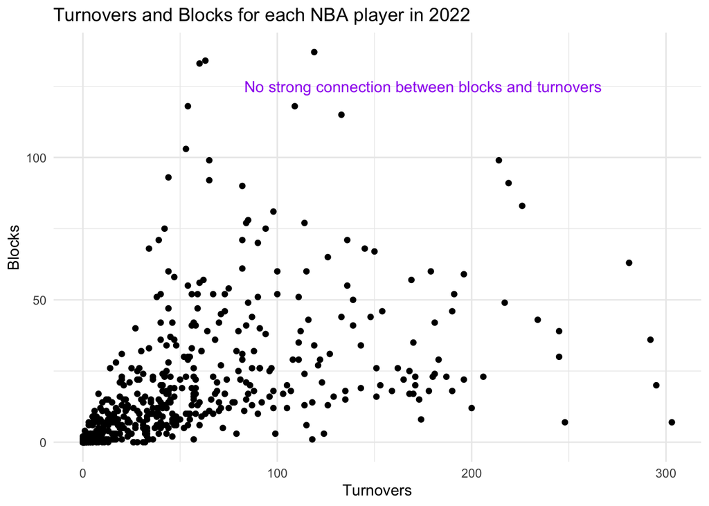

```r
# your code
ggplot(data = dat, aes(x = turnovers, y = blocks)) +
  geom_point() +
  labs(title = "Turnovers and Blocks for each NBA player in 2022",
       x = "Turnovers",
       y = "Blocks") +
  theme_minimal() +
  annotate(geom = "text", x = 175, y = 125, label = "No strong connection between blocks and turnovers", color = "purple")
```

## 2.3 Height and Blocks

**Do taller players tend to obtain more blocks?** Generate a graphic that lets you see if taller players are able to achieve more blocks.

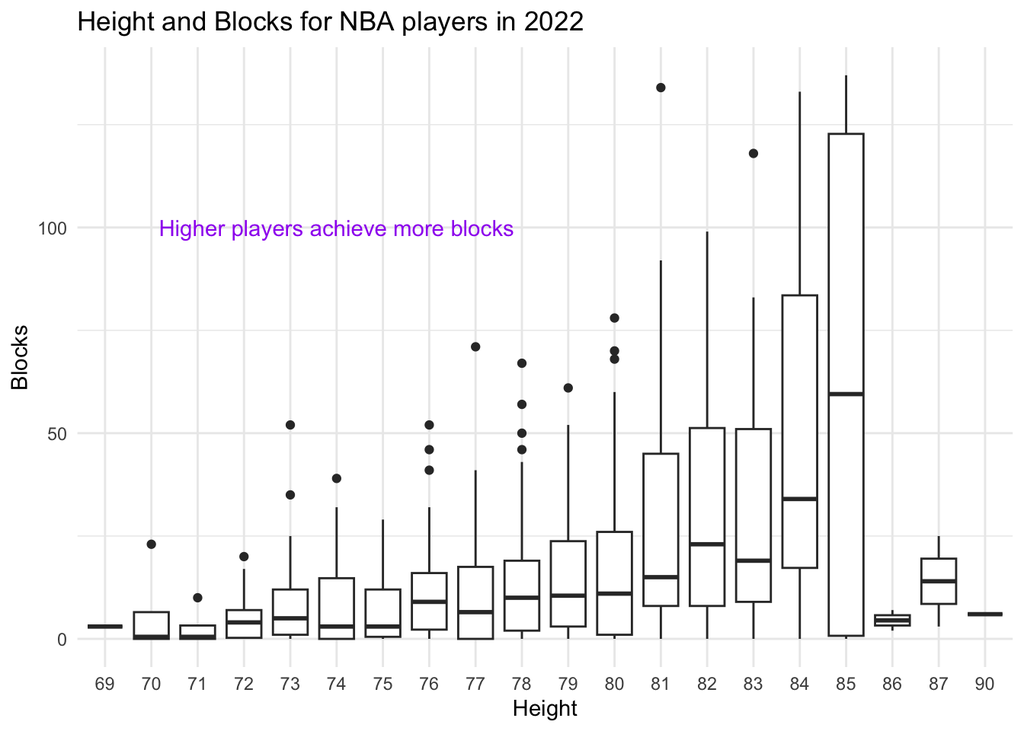

```r
# your code
ggplot(data = dat, aes(x = factor(height), y = blocks)) +
  geom_boxplot() +
  labs(title = "Height and Blocks for NBA players in 2022",
       x = "Height",
       y = "Blocks") +
  theme_minimal() +
  annotate(geom = "text", x = 6, y = 100, label = "Higher players achieve more blocks", color = "purple")
```

# 3 Very open-ended

**Important**

- All the graphics must include a meaningful title.
- Make sure axes are labeled.

## 3.1 Shooting Guards

According to Wikipedia:

> “The shooting guard (SG)—also known as the two or the off guard—is, along with the small forward, often referred to as a wing because of its use in common positioning tactics. As the name suggests, most shooting guards are prolific from three-point range and long mid-range… In the NBA, a shooting guard is generally between 6 feet 2 inches (1.88 m) to 6 feet 7 inches (2 m).”

https://en.wikipedia.org/wiki/Basketball_positions

Make at least 2 graphics that allow you to either confirm or reject Wikipedia’s claim about Shooting Guards.

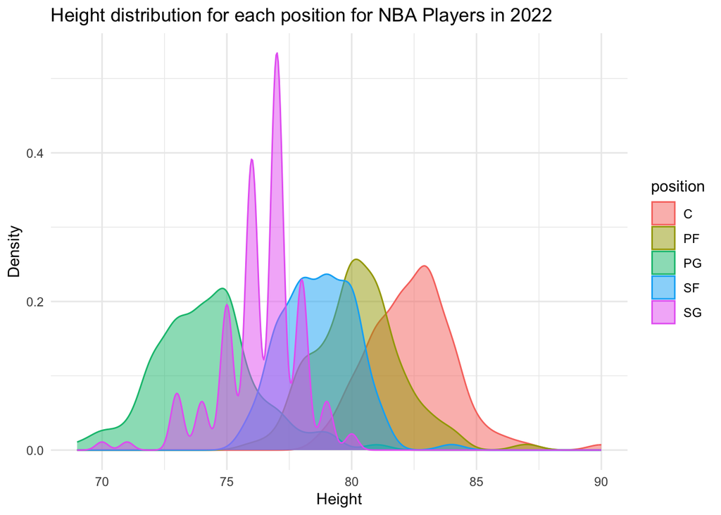

```r
# your code
ggplot(data = dat, aes(x = height, color = position)) +
  geom_density(aes(fill = position), alpha = 0.5) +
  labs(title = "Height distribution for each position for NBA Players in 2022",
       x = "Height",
       y = "Density") +
  theme_minimal()
```

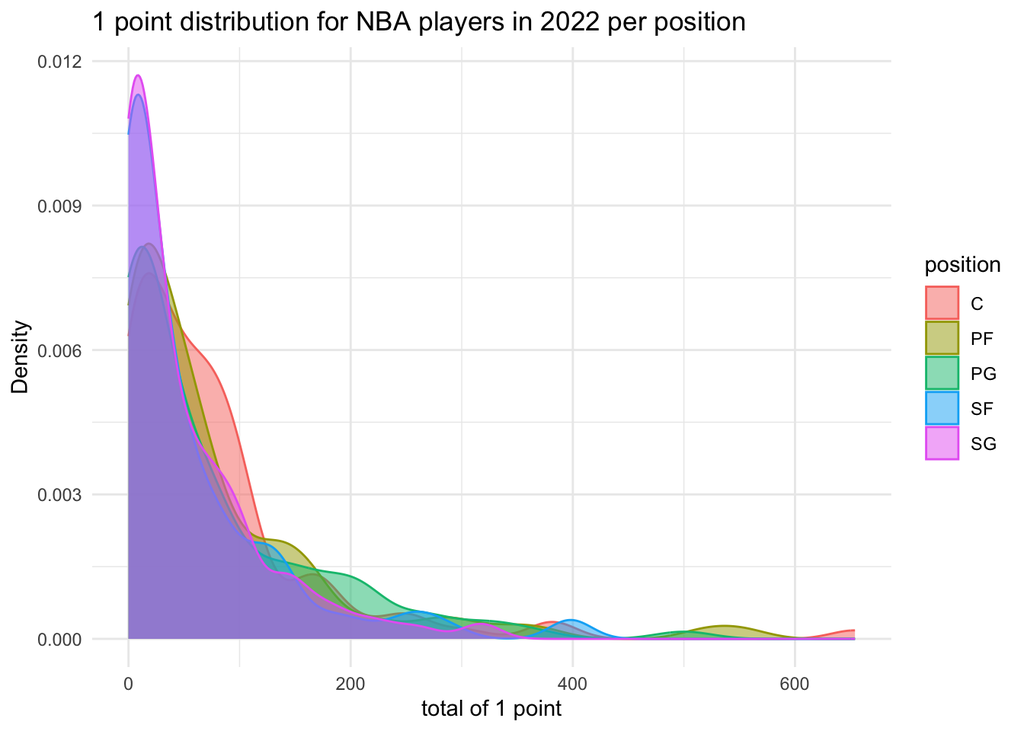

```r
ggplot(data = dat, aes(x = points1, color = position)) +
  geom_density(aes(fill = position), alpha = 0.5) +
  labs(title = "1 point distribution for NBA players in 2022 per position",
       x = "total of 1 point",
       y = "Density") +
  theme_minimal()
```

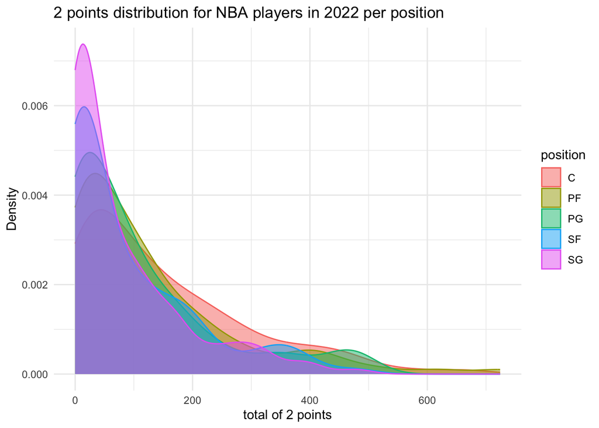

```r
ggplot(data = dat, aes(x = points2, color = position)) +
  geom_density(aes(fill = position), alpha = 0.5) +
  labs(title = "2 points distribution for NBA players in 2022 per position",
       x = "total of 2 points",
       y = "Density") +
  theme_minimal()
```

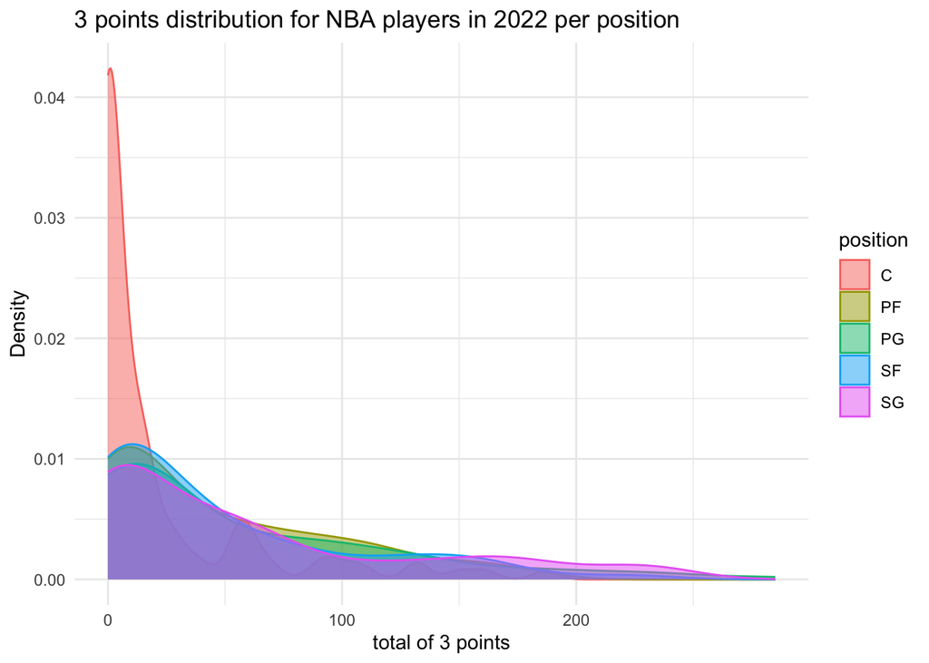

```r
ggplot(data = dat, aes(x = points3, color = position)) +
  geom_density(aes(fill = position), alpha = 0.5) +
  labs(title = "3 points distribution for NBA players in 2022 per position",
       x = "total of 3 points",
       y = "Density") +
  theme_minimal()
```

# Rubric

- 😞 **None (0 pts)**: No submission; or terribly wrong; or incorrect files.
- 😟 **Deficient (1 pt)**: Displays minimal effort. Fairly incomplete. Code is poorly written and not documented.
- 🙁 **Needs improvement (2 pts)**: Displays some effort. Doesn’t complete all components. Code is poorly written and not documented. Just contains code and output but no descriptions, explanations or interpretations. Uses the same type of plot for each graph, or doesn’t use plots appropriate for the variables being analyzed. Possibly a major issue or mistake.
- 😐 **Fair (3 pts)**: Decent effort. Hits all the elements. Possibly a couple of minor mistakes or some non-minor issue. Code is okay, but there is room for better comments, and/or format. Fairly basic plots produced with default settings (i.e. minimal or no customization). Nothing spectacular, either bad or good.
- 🙂 **Good (4 pts)**: Solid effort. Hits all the elements. Possibly a minor mistake. Easy to follow (both the code and the output). Most plots are customized (labels, colors, theme, etc). Takes care of well presented information (e.g. proper use of markdown elements, no spelling issues, well organized).
- 😀 **Excellent (5 pts)**: Finished all components of the assignment correctly. Code is well-documented (both self-documented and with additional comments as necessary). Graphs properly labeled/annotated. Uses non-default settings, highly customizing the graphics to give them an outstanding appearance (i.e. publication quality). Descriptions are clear and easy to follow, either because graphs are labeled clearly or you’ve written additional text to describe how you interpret the output. Spectacular submission, that can be used as an *exemplary solution*.